# Loan Data Exploration

## Preliminary Wrangling

This document explores a loan dataset containing 113,937 loans with 81 variables on each loan. It will focus the analysis on around 10 variables.

```python
# import all packages and set plots to be embedded inline
import numpy as np
import pandas as pd
import matplotlib.pyplot as plt
import seaborn as sb

%matplotlib inline
```

```python
# load in the dataset

loans = pd.read_csv('prosperLoanData.csv')
```

```python
# get some basic info on the dataset

loans.info()
```

```
<class 'pandas.core.frame.DataFrame'>
RangeIndex: 113937 entries, 0 to 113936
Data columns (total 81 columns):
ListingKey                             113937 non-null object
ListingNumber                          113937 non-null int64
ListingCreationDate                    113937 non-null object
CreditGrade                            28953 non-null object
Term                                   113937 non-null int64
LoanStatus                             113937 non-null object
ClosedDate                             55089 non-null object
BorrowerAPR                            113912 non-null float64
BorrowerRate                           113937 non-null float64
LenderYield                            113937 non-null float64
EstimatedEffectiveYield                84853 non-null float64
EstimatedLoss                          84853 non-null float64
EstimatedReturn                        84853 non-null float64
ProsperRating (numeric)                84853 non-null float64
ProsperRating (Alpha)                  84853 non-null object
ProsperScore                           84853 non-null float64
ListingCategory (numeric)              113937 non-null int64
BorrowerState                          108422 non-null object
Occupation                             110349 non-null object
EmploymentStatus                       111682 non-null object
EmploymentStatusDuration               106312 non-null float64
IsBorrowerHomeowner                    113937 non-null bool
CurrentlyInGroup                       113937 non-null bool
GroupKey                               13341 non-null object
DateCreditPulled                       113937 non-null object
CreditScoreRangeLower                  113346 non-null float64
CreditScoreRangeUpper                  113346 non-null float64
FirstRecordedCreditLine                113240 non-null object
CurrentCreditLines                     106333 non-null float64
OpenCreditLines                        106333 non-null float64
TotalCreditLinespast7years             113240 non-null float64
OpenRevolvingAccounts                  113937 non-null int64
OpenRevolvingMonthlyPayment            113937 non-null float64
InquiriesLast6Months                   113240 non-null float64
TotalInquiries                         112778 non-null float64
CurrentDelinquencies                   113240 non-null float64
AmountDelinquent                       106315 non-null float64
```

[output cut: 31 more lines]

```
LP_CustomerPayments                    113937 non-null float64
LP_CustomerPrincipalPayments           113937 non-null float64
LP_InterestandFees                     113937 non-null float64
LP_ServiceFees                         113937 non-null float64
LP_CollectionFees                      113937 non-null float64
LP_GrossPrincipalLoss                  113937 non-null float64
LP_NetPrincipalLoss                    113937 non-null float64
LP_NonPrincipalRecoverypayments        113937 non-null float64
PercentFunded                          113937 non-null float64
Recommendations                        113937 non-null int64
InvestmentFromFriendsCount             113937 non-null int64
InvestmentFromFriendsAmount            113937 non-null float64
Investors                              113937 non-null int64
dtypes: bool(3), float64(50), int64(11), object(17)
memory usage: 68.1+ MB
```

```python
# let's have a look at some sample data to study the data a bit more

loans.head(10)
```

|  | ListingKey | ListingNumber | ListingCreationDate | CreditGrade | Term | LoanStatus | ClosedDate | BorrowerAPR | BorrowerRate | LenderYield | ... | LP_ServiceFees | LP_CollectionFees | LP_GrossPrincipalLoss | LP_NetPrincipalLoss | LP_NonPrincipalRecoverypayments | PercentFunded | Recommendations | InvestmentFromFriendsCount | InvestmentFromFriendsAmount | Investors |
| --- | --- | --- | --- | --- | --- | --- | --- | --- | --- | --- | --- | --- | --- | --- | --- | --- | --- | --- | --- | --- | --- |
| 0 | 1021339766868145413AB3B | 193129 | 2007-08-26 19:09:29.263000000 | C | 36 | Completed | 2009-08-14 00:00:00 | 0.16516 | 0.1580 | 0.1380 | ... | -133.18 | 0.0 | 0.0 | 0.0 | 0.0 | 1.0 | 0 | 0 | 0.0 | 258 |
| 1 | 10273602499503308B223C1 | 1209647 | 2014-02-27 08:28:07.900000000 | NaN | 36 | Current | NaN | 0.12016 | 0.0920 | 0.0820 | ... | 0.00 | 0.0 | 0.0 | 0.0 | 0.0 | 1.0 | 0 | 0 | 0.0 | 1 |
| 2 | 0EE9337825851032864889A | 81716 | 2007-01-05 15:00:47.090000000 | HR | 36 | Completed | 2009-12-17 00:00:00 | 0.28269 | 0.2750 | 0.2400 | ... | -24.20 | 0.0 | 0.0 | 0.0 | 0.0 | 1.0 | 0 | 0 | 0.0 | 41 |
| 3 | 0EF5356002482715299901A | 658116 | 2012-10-22 11:02:35.010000000 | NaN | 36 | Current | NaN | 0.12528 | 0.0974 | 0.0874 | ... | -108.01 | 0.0 | 0.0 | 0.0 | 0.0 | 1.0 | 0 | 0 | 0.0 | 158 |
| 4 | 0F023589499656230C5E3E2 | 909464 | 2013-09-14 18:38:39.097000000 | NaN | 36 | Current | NaN | 0.24614 | 0.2085 | 0.1985 | ... | -60.27 | 0.0 | 0.0 | 0.0 | 0.0 | 1.0 | 0 | 0 | 0.0 | 20 |
| 5 | 0F05359734824199381F61D | 1074836 | 2013-12-14 08:26:37.093000000 | NaN | 60 | Current | NaN | 0.15425 | 0.1314 | 0.1214 | ... | -25.33 | 0.0 | 0.0 | 0.0 | 0.0 | 1.0 | 0 | 0 | 0.0 | 1 |
| 6 | 0F0A3576754255009D63151 | 750899 | 2013-04-12 09:52:56.147000000 | NaN | 36 | Current | NaN | 0.31032 | 0.2712 | 0.2612 | ... | -22.95 | 0.0 | 0.0 | 0.0 | 0.0 | 1.0 | 0 | 0 | 0.0 | 1 |
| 7 | 0F1035772717087366F9EA7 | 768193 | 2013-05-05 06:49:27.493000000 | NaN | 36 | Current | NaN | 0.23939 | 0.2019 | 0.1919 | ... | -69.21 | 0.0 | 0.0 | 0.0 | 0.0 | 1.0 | 0 | 0 | 0.0 | 1 |
| 8 | 0F043596202561788EA13D5 | 1023355 | 2013-12-02 10:43:39.117000000 | NaN | 36 | Current | NaN | 0.07620 | 0.0629 | 0.0529 | ... | -16.77 | 0.0 | 0.0 | 0.0 | 0.0 | 1.0 | 0 | 0 | 0.0 | 1 |
| 9 | 0F043596202561788EA13D5 | 1023355 | 2013-12-02 10:43:39.117000000 | NaN | 36 | Current | NaN | 0.07620 | 0.0629 | 0.0529 | ... | -16.77 | 0.0 | 0.0 | 0.0 | 0.0 | 1.0 | 0 | 0 | 0.0 | 1 |

10 rows × 81 columns

```python
# let's have a look at some stats

loans.describe()
```

|  | ListingNumber | Term | BorrowerAPR | BorrowerRate | LenderYield | EstimatedEffectiveYield | EstimatedLoss | EstimatedReturn | ProsperRating (numeric) | ProsperScore | ... | LP_ServiceFees | LP_CollectionFees | LP_GrossPrincipalLoss | LP_NetPrincipalLoss | LP_NonPrincipalRecoverypayments | PercentFunded | Recommendations | InvestmentFromFriendsCount | InvestmentFromFriendsAmount | Investors |
| --- | --- | --- | --- | --- | --- | --- | --- | --- | --- | --- | --- | --- | --- | --- | --- | --- | --- | --- | --- | --- | --- |
| count | 1.139370e+05 | 113937.000000 | 113912.000000 | 113937.000000 | 113937.000000 | 84853.000000 | 84853.000000 | 84853.000000 | 84853.000000 | 84853.000000 | ... | 113937.000000 | 113937.000000 | 113937.000000 | 113937.000000 | 113937.000000 | 113937.000000 | 113937.000000 | 113937.000000 | 113937.000000 | 113937.000000 |
| mean | 6.278857e+05 | 40.830248 | 0.218828 | 0.192764 | 0.182701 | 0.168661 | 0.080306 | 0.096068 | 4.072243 | 5.950067 | ... | -54.725641 | -14.242698 | 700.446342 | 681.420499 | 25.142686 | 0.998584 | 0.048027 | 0.023460 | 16.550751 | 80.475228 |
| std | 3.280762e+05 | 10.436212 | 0.080364 | 0.074818 | 0.074516 | 0.068467 | 0.046764 | 0.030403 | 1.673227 | 2.376501 | ... | 60.675425 | 109.232758 | 2388.513831 | 2357.167068 | 275.657937 | 0.017919 | 0.332353 | 0.232412 | 294.545422 | 103.239020 |
| min | 4.000000e+00 | 12.000000 | 0.006530 | 0.000000 | -0.010000 | -0.182700 | 0.004900 | -0.182700 | 1.000000 | 1.000000 | ... | -664.870000 | -9274.750000 | -94.200000 | -954.550000 | 0.000000 | 0.700000 | 0.000000 | 0.000000 | 0.000000 | 1.000000 |
| 25% | 4.009190e+05 | 36.000000 | 0.156290 | 0.134000 | 0.124200 | 0.115670 | 0.042400 | 0.074080 | 3.000000 | 4.000000 | ... | -73.180000 | 0.000000 | 0.000000 | 0.000000 | 0.000000 | 1.000000 | 0.000000 | 0.000000 | 0.000000 | 2.000000 |
| 50% | 6.005540e+05 | 36.000000 | 0.209760 | 0.184000 | 0.173000 | 0.161500 | 0.072400 | 0.091700 | 4.000000 | 6.000000 | ... | -34.440000 | 0.000000 | 0.000000 | 0.000000 | 0.000000 | 1.000000 | 0.000000 | 0.000000 | 0.000000 | 44.000000 |
| 75% | 8.926340e+05 | 36.000000 | 0.283810 | 0.250000 | 0.240000 | 0.224300 | 0.112000 | 0.116600 | 5.000000 | 8.000000 | ... | -13.920000 | 0.000000 | 0.000000 | 0.000000 | 0.000000 | 1.000000 | 0.000000 | 0.000000 | 0.000000 | 115.000000 |
| max | 1.255725e+06 | 60.000000 | 0.512290 | 0.497500 | 0.492500 | 0.319900 | 0.366000 | 0.283700 | 7.000000 | 11.000000 | ... | 32.060000 | 0.000000 | 25000.000000 | 25000.000000 | 21117.900000 | 1.012500 | 39.000000 | 33.000000 | 25000.000000 | 1189.000000 |

8 rows × 61 columns

### Dataset Structure

There are 113,937 loans in the dataset with 81 features. Most variables are numeric or dates in nature, but some are texts like occupation and employment status.

### Main Feature of Interest

For this exploration, I will look into the borrower annual percentage rate (`BorrowerAPR`). I want to learn about what features in the dataset influences this rate.

### Features to Support the Investigation

I feel that the main determining factor of the borrower APR is the borrower's employment details. As such, I will look into `EmploymentStatus`, `EmploymentStatusDuration`, `IncomeRange` and `IncomeVerifiable` closely. I'll also expand my exploration to some other features like `OpenCreditLines`, `CurrentCreditLines`, `CreditScoreRangeLower`, `CreditScoreRangeUpper`, and `LoanOriginalAmount`.

## Univariate Exploration

In this section, I'll look into the distributions of each individual features. Let's start with the feature of interest and then move to most interesting employment related ones in this order: `EmploymentStatus`, `EmploymentStatusDuration`, `IncomeRange` and `IncomeVerifiable`.

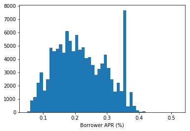

```python
# let's explore the BorrowerAPR distribution

bin_size = 0.01
bins = np.arange(0.05, loans['BorrowerAPR'].max()+bin_size, bin_size)

plt.hist(data = loans, x = 'BorrowerAPR', bins = bins)
plt.xlabel('Borrower APR (%)')
plt.show()
```

Interestingly, there is a spike in the borrower APR at approximately 0.35%. The distribution is slightly right skewed.

Let's now look at `EmploymentStatus`

```python
# let's now look at EmploymentStatus

loans['EmploymentStatus'].value_counts()
```

```
Employed         67322
Full-time        26355
Self-employed     6134
Not available     5347
Other             3806
Part-time         1088
Not employed       835
Retired            795
Name: EmploymentStatus, dtype: int64
```

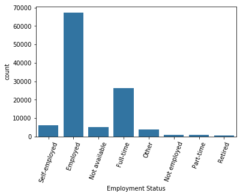

```python
# let's plot EmploymentStatus data

default_color = sb.color_palette()[0]
sb.countplot(data = loans, x = 'EmploymentStatus', color = default_color);
plt.xlabel('Employment Status');
plt.xticks(rotation=70);
```

This data is relatively unclear. For example, the status 'Employed' is very general and could very well be 'Full-time', 'Self-employed' or 'Part-time'. It also seems that most of the data falls within the 'Employed' status. The data is not ordered as there is no clear way to order it.

I'll now move on to look at `EmploymentStatusDuration`.

```python
# let's look at EmploymentStatusDuration

loans['EmploymentStatusDuration'].describe()
```

```
count    106312.000000
mean         96.071582
std          94.480605
min           0.000000
25%          26.000000
50%          67.000000
75%         137.000000
max         755.000000
Name: EmploymentStatusDuration, dtype: float64
```

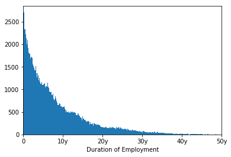

```python
# let's plot EmploymentStatusDuration data

bin_size = 2
bins = np.arange(0, loans['EmploymentStatusDuration'].max()+bin_size, bin_size)

plt.hist(data = loans, x = 'EmploymentStatusDuration', bins = bins);
plt.xlabel('Duration of Employment');
plt.xticks([0, 120, 240, 360, 480, 600],['0', '10y', '20y', '30y', '40y', '50y'])
plt.xlim(0, 600)
plt.show()
```

Since there are lots of loans given to people who have been employed for less than 5 years and there is a long tail, we will plot this on a log scale.

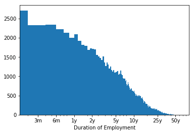

```python
# plot EmploymentStatusDuration data on log scale

bin_size = 2
bins = np.arange(0, loans['EmploymentStatusDuration'].max()+bin_size, bin_size)

plt.hist(data = loans, x = 'EmploymentStatusDuration', bins = bins);
plt.xscale('log')
plt.xlabel('Duration of Employment');
plt.xticks([3, 6, 12, 24, 60, 120, 300, 600],['3m', '6m', '1y', '2y', '5y', '10y', '25y', '50y'])
plt.show()
```

Strangely, there are a lot of loans given to people with 2 months or less employment duration. We'll check this.

```python
# check people with employment duration of 0

data = loans[loans['EmploymentStatusDuration'] == 0]
data[['EmploymentStatus', 'EmploymentStatusDuration', 'IncomeRange', 'IncomeVerifiable']].head(5)
```

|  | EmploymentStatus | EmploymentStatusDuration | IncomeRange | IncomeVerifiable |
| --- | --- | --- | --- | --- |
| 51 | Employed | 0.0 | $50,000-74,999 | True |
| 161 | Other | 0.0 | $25,000-49,999 | True |
| 443 | Full-time | 0.0 | $25,000-49,999 | True |
| 532 | Other | 0.0 | $100,000+ | True |
| 556 | Other | 0.0 | $25,000-49,999 | True |

Looking at the data above, it's a bit odd that there are people employed with a verified income but with the employment status duration as 0. We'll remove this outlier.

```python
# remove loans data with employment status duration as 0 and check

loans = loans[loans['EmploymentStatusDuration'] != 0]
assert len(loans[loans['EmploymentStatusDuration'] == 0]) == 0
```

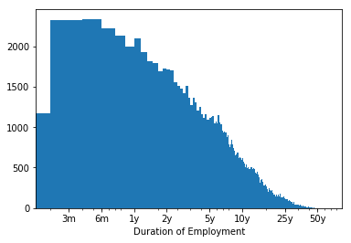

```python
# try replotting the distribution

bin_size = 2
bins = np.arange(0, loans['EmploymentStatusDuration'].max()+bin_size, bin_size)

plt.hist(data = loans, x = 'EmploymentStatusDuration', bins = bins);
plt.xscale('log')
plt.xlabel('Duration of Employment');
plt.xticks([3, 6, 12, 24, 60, 120, 300, 600],['3m', '6m', '1y', '2y', '5y', '10y', '25y', '50y'])
plt.show()
```

We'll now move on to `IncomeRange`.

```python
# let's look at IncomeRange data

loans['IncomeRange'].value_counts()
```

```
$25,000-49,999    31615
$50,000-74,999    30698
$100,000+         17237
$75,000-99,999    16784
Not displayed      7732
$1-24,999          6981
Not employed        761
$0                  595
Name: IncomeRange, dtype: int64
```

```python
# let's order this data appropriately

order = ['$100,000+', '$75,000-99,999', '$50,000-74,999', '$25,000-49,999', '$1-24,999', '$0', 'Not displayed', 'Not employed']
ordered_income = pd.api.types.CategoricalDtype(ordered = True, categories = order)
loans['IncomeRange'] = loans['IncomeRange'].astype(ordered_income)
```

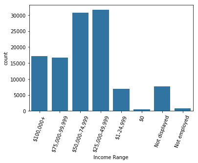

```python
# let's plot IncomeRange data

default_color = sb.color_palette()[0]
sb.countplot(data = loans, x = 'IncomeRange', color = default_color);
plt.xlabel('Income Range');
plt.xticks(rotation=70);
```

Looking at income data, it seems the majority of users fall between 25k to 75k dollars. Strangely, there are some people earning 0 dollars. We will check this.

```python
# check people earning $0

data = loans[loans['IncomeRange'] == '$0']
data[['EmploymentStatus', 'EmploymentStatusDuration', 'IncomeRange', 'IncomeVerifiable', 'StatedMonthlyIncome']].head(5)
```

|  | EmploymentStatus | EmploymentStatusDuration | IncomeRange | IncomeVerifiable | StatedMonthlyIncome |
| --- | --- | --- | --- | --- | --- |
| 78 | Full-time | 68.0 | $0 | False | 0.0 |
| 108 | Full-time | 27.0 | $0 | False | 0.0 |
| 772 | Full-time | 2.0 | $0 | False | 0.0 |
| 954 | Full-time | 54.0 | $0 | False | 0.0 |
| 1346 | Self-employed | 15.0 | $0 | False | 0.0 |

It appears a bit odd but we can't verify that it's false either. For the purpose of this analysis, we will remove income ranges 0 dollars and Not displayed, as we won't be able to use them to measure the effects on `BorrowerAPR`.

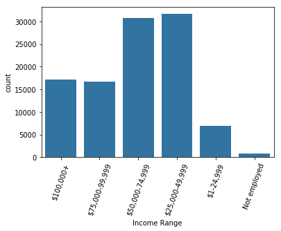

```python
# Remove $0 and Not displayed data from IncomeRange, test and replot

loans = loans[loans['IncomeRange'] != '$0']
loans = loans[loans['IncomeRange'] != 'Not displayed']

order = ['$100,000+', '$75,000-99,999', '$50,000-74,999', '$25,000-49,999', '$1-24,999', 'Not employed']
ordered_income = pd.api.types.CategoricalDtype(ordered = True, categories = order)
loans['IncomeRange'] = loans['IncomeRange'].astype(ordered_income)

assert len(loans[loans['IncomeRange'] == '$0']) == 0
assert len(loans[loans['IncomeRange'] == 'Not displayed']) == 0

default_color = sb.color_palette()[0]
sb.countplot(data = loans, x = 'IncomeRange', color = default_color);
plt.xlabel('Income Range');
plt.xticks(rotation=70);
plt.show()
```

We will now look into `IncomeVeriable` data

```python
# look into IncomeVerifiable data

loans['IncomeVerifiable'].value_counts()
```

```
True     96309
False     7767
Name: IncomeVerifiable, dtype: int64
```

```
92.54% Verified
```

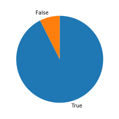

```python
# plot IncomeVerifiable data

IncomeVerifiable = loans['IncomeVerifiable'].value_counts()

plt.pie(IncomeVerifiable, labels = IncomeVerifiable.index, startangle = 90, counterclock = False);

print(str(round(IncomeVerifiable[True]/(IncomeVerifiable[False]+IncomeVerifiable[True])*100, 2)) + '% Verified')
```

Let's move to other features of interest (`OpenCreditLines`, `CreditScoreRangeLower`, `CreditScoreRangeUpper`, `LoanOriginalAmount` and `IsBorrowerHomeowner`). We'll start with `OpenCreditLines`.

```python
# explore OpenCreditLines data

print("NaN values: " + str(sum(pd.isnull(loans['OpenCreditLines']))))
loans[['OpenCreditLines']].describe()
```

```
NaN values: 1
```

|  | OpenCreditLines |
| --- | --- |
| count | 104075.000000 |
| mean | 9.282460 |
| std | 5.019327 |
| min | 0.000000 |
| 25% | 6.000000 |
| 50% | 9.000000 |
| 75% | 12.000000 |
| max | 54.000000 |

```python
# drop NaN values and check

loans = loans[pd.notnull(loans['OpenCreditLines'])]
assert sum(pd.isnull(loans['OpenCreditLines'])) == 0
```

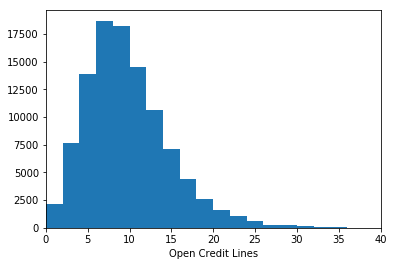

```python
# plot OpenCreditLines data

bin_size = 2
bins = np.arange(0, loans['OpenCreditLines'].max() + bin_size, bin_size)

plt.hist(data = loans, x = 'OpenCreditLines', bins = bins)
plt.xlabel('Open Credit Lines')
plt.xlim(0, 40)
plt.show()
```

`OpenCreditLines` data show that the majority of people on these loans have had open credit lines when they got the loan. Most of then between 5-15 credit lines. The distribution is right skewed.

We'll now move on to look at `CreditScoreRangeLower` and `CreditScoreRangeUpper`.

```python
# explore CreditScoreRangeLower and CreditScoreRangeUpper data

loans[['CreditScoreRangeLower', 'CreditScoreRangeUpper']].describe()
```

|  | CreditScoreRangeLower | CreditScoreRangeUpper |
| --- | --- | --- |
| count | 104075.000000 | 104075.000000 |
| mean | 691.460773 | 710.460773 |
| std | 56.245762 | 56.245762 |
| min | 520.000000 | 539.000000 |
| 25% | 660.000000 | 679.000000 |
| 50% | 680.000000 | 699.000000 |
| 75% | 720.000000 | 739.000000 |
| max | 880.000000 | 899.000000 |

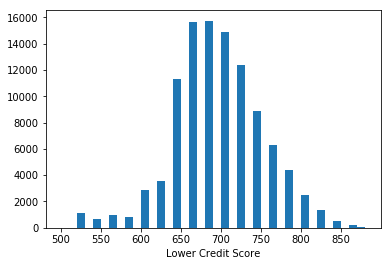

```python
# plot CreditScoreRangeLower data

bin_size = 10
bins = np.arange(500, loans['CreditScoreRangeLower'].max() + bin_size, bin_size)

plt.hist(data = loans, x ='CreditScoreRangeLower', bins = bins)
plt.xlabel('Lower Credit Score')
plt.show()
```

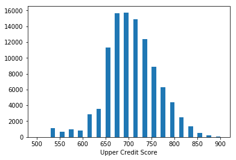

```python
# plot CreditScoreRangeUpper data

bin_size = 10
bins = np.arange(500, loans['CreditScoreRangeUpper'].max() + bin_size, bin_size)

plt.hist(data = loans, x ='CreditScoreRangeUpper', bins = bins)
plt.xlabel('Upper Credit Score')
plt.show()
```

The lower and upper credit ranges are binomial distributions and they show that most people's credit score fall between 650 and 750. To simplify our analysis, we will create a mean credit score variable in the data and use this.

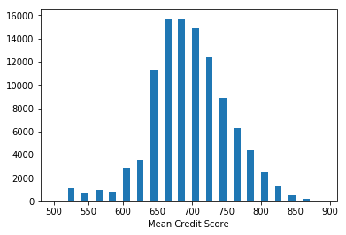

```python
# create mean credit score data and plot it

loans['CreditScoreRangeMean'] = (loans['CreditScoreRangeLower']+loans['CreditScoreRangeUpper'])/2

bin_size = 10
bins = np.arange(500, loans['CreditScoreRangeMean'].max() + bin_size, bin_size)

plt.hist(data = loans, x ='CreditScoreRangeMean', bins = bins)
plt.xlabel('Mean Credit Score')
plt.show()
```

Now, we'll move on to `LoanOriginalAmount`.

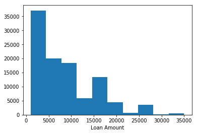

```python
# Plot the distribution for the original loan amount

bin_size = 100
bins = np.arange(0, loans['LoanOriginalAmount'].max() + bin_size, bin_size)

plt.hist(data = loans, x = 'LoanOriginalAmount')
plt.xlabel('Loan Amount')
plt.show()
```

Looking at this data we can see that most people request loans under 10,000 dollars. The data distribution is right skewed.

Lastly, we'll look at `IsBorrowerHomeowner`.

```python
# Check IsBorrowerHomeowner distribution

loans['IsBorrowerHomeowner'].value_counts()
```

```
True     53989
False    50086
Name: IsBorrowerHomeowner, dtype: int64
```

```
51.88% has a mortgage
```

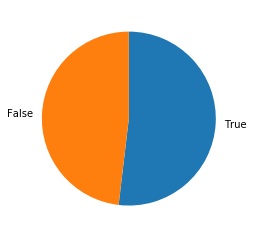

```python
# Plot IsBorrowerHomeowner distribution

IsBorrowerHomeowner = loans['IsBorrowerHomeowner'].value_counts()

plt.pie(IsBorrowerHomeowner, labels = IsBorrowerHomeowner.index, startangle = 90, counterclock = False);

print(str(round(IsBorrowerHomeowner[True]/(IsBorrowerHomeowner[False]+IsBorrowerHomeowner[True])*100, 2)) + '% has a mortgage')
```

Just over half of the loans are owned by people who have a mortgage (51.88%). It would be interesting as to how to effects their `BorrowerAPR`.

### Univariate Exploration Summary

The distribution of the main variable of interest (`BorrowerAPR`) was slightly right skewed, however, there was an interesting spike in the data at approximately 0.35%. Most of the other distributions were also right skewed.

For the `EmploymentStatusDuration` a log transformation was performed as a lot of the data was concentrated within 0-5 years duration.

Some of the features in the dataset had unusual points. For example, there are people earning 0 dollars and being employed for many months. Also, there were people with an employment duration of 0 months but have verified employment. These outliers were removed for safety.

## Bivariate Exploration

In this section, we will look at relationships between variables explored in the last section. To start, we will check the variables for any correlations.

```python
numeric_vars = ['BorrowerAPR', 'EmploymentStatusDuration', 'OpenCreditLines',
                'CreditScoreRangeMean', 'LoanOriginalAmount']
categoric_vars = ['IncomeVerifiable', 'IncomeRange', 'EmploymentStatus', 'IsBorrowerHomeowner']
```

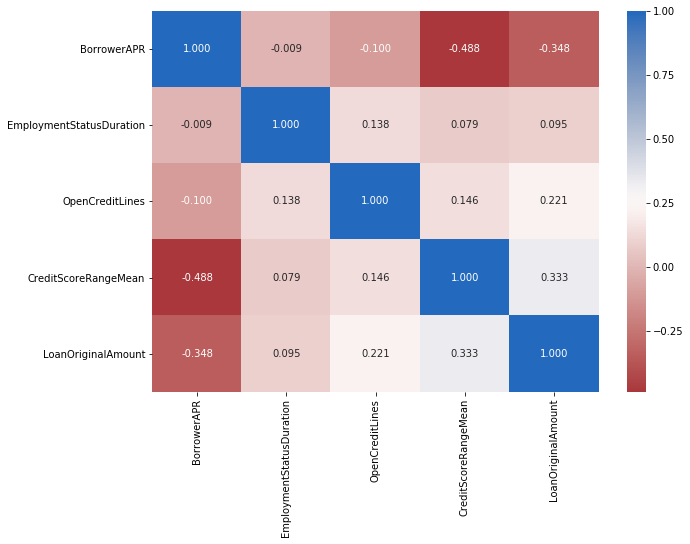

```python
# create a correlation plot

plt.figure(figsize = [10, 7])
sb.heatmap(loans[numeric_vars].corr(), annot = True, fmt = '.3f', cmap = 'vlag_r')
plt.show()
```

Looking at the heat map above, interestingly, there's not a lot of variables correlating with `BorrowerAPR`. We'll now look at the plots to be sure.

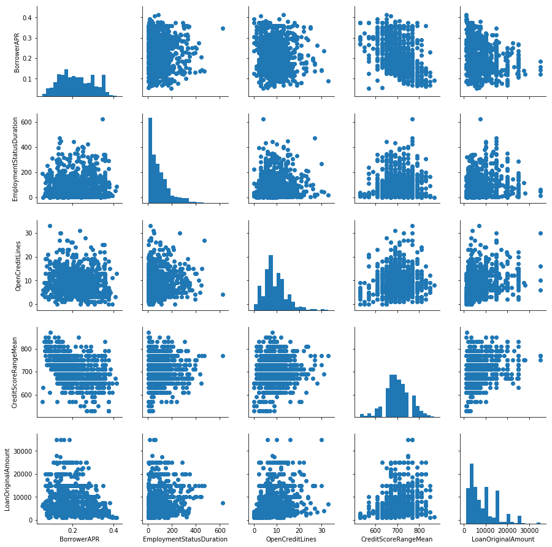

```python
# plot matrix of sample of 1000 loans

samples = np.random.choice(loans.shape[0], 1000, replace = False)
loans_samp = loans.loc[samples,:]

g = sb.PairGrid(data = loans_samp, vars = numeric_vars);
g = g.map_diag(plt.hist, bins = 20);
g.map_offdiag(plt.scatter);
```

Looking at the matrix above shows that, of the numeric data being analysed, `BorrowerAPR` is not strongly correlated with any variables. It does have a negative correlation with the Credit Score. Although, this is not a strong negative correlation. `BorrowerAPR` seems to also be lower for bigger loan amounts. This is presumably to avoid it costing the borrower too much. There is also a positive correlation between loan amount and credit score, showing that larger loans are usually only given when the credit scores are higher.

I will explore the relationship between `BorrowerAPR` and `CreditScoreRangeMean` and between `BorrowerAPR` and `LoanOriginalAmount` further as it shows a bit of correlation.

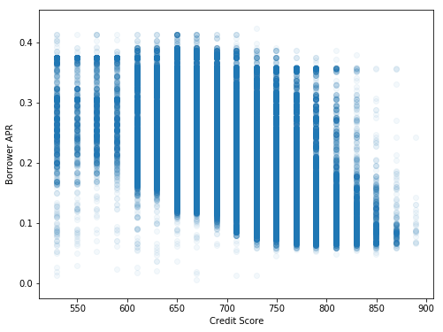

```python
# Produce a scatter plot between BorrowerAPR and CreditScoreRangeMean

plt.figure(figsize = [8, 6])
plt.scatter(data = loans, x = 'CreditScoreRangeMean', y = 'BorrowerAPR', alpha = 0.05)
plt.xlabel('Credit Score')
plt.ylabel('Borrower APR')
plt.show()
```

This is quite interesting. Loans are being given out at all ranges of credit score. However, lower credit scores tend to attract a higher Borrower APR. Although, not strong, there is clearly a negative correlation between `BorrowerAPR` and `CreditScoreRangeMean`.

Now, let's look at the relationship between `BorrowerAPR` and `LoanOriginalAmount` further below.

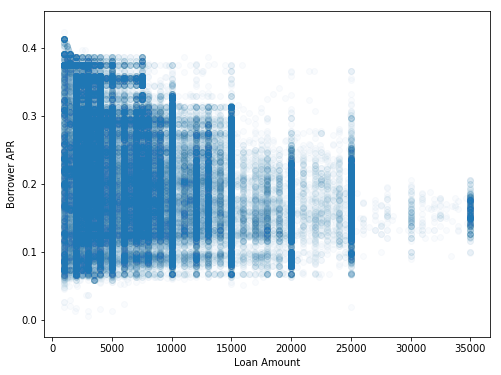

```python
# Produce a scatter plot between BorrowerAPR and LoanOriginalAmount

plt.figure(figsize = [8, 6])
plt.scatter(data = loans, x = 'LoanOriginalAmount', y = 'BorrowerAPR', alpha = 0.025)
plt.xlabel('Loan Amount')
plt.ylabel('Borrower APR')
plt.show()
```

We see from the above plot that generally the higher the loan amount, the more `BorrowerAPR` is distributed in the lower range (more focused).

Now, let's look at how `BorrowerAPR` relate to the categorical variables.

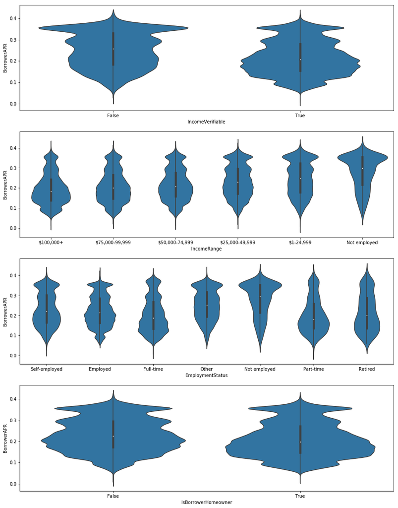

```python
# Plot categorical variables with Borrower APR and Credit Score

fig, ax = plt.subplots(ncols = 1, nrows = 4 , figsize = [15,20])

for i in range(len(categoric_vars)):
    var = categoric_vars[i]
    sb.violinplot(data = loans, x = var, y = 'BorrowerAPR', ax = ax[i], color = default_color)

plt.show()
```

Looking at the violin plots above, there are some interesting insights.

- The distributions for the 2 `IncomeVerifiable` categories show that loans which has a verified income generally have a lower `BorrowerAPR`. Vice versa, those loans with incomes not verified mainly fall in the ranges of higher `BorrowerAPR`.
- Income range seems to have a clear impact on `BorrowerAPR` as well. The lower the income, the more loans we see have a higher `BorrowerAPR`.
- Looking at `EmploymentStatus` and `BorrowerAPR` shows that those that are not employed have a higher `BorrowerAPR`. It is interesting to see that loans with part time employment has a similar `BorrowerAPR` distribution to full time employment.
- Also interestingly, Being a home loan owner doesn't seem to effect `BorrowerAPR` too much.

Now, let's look at how the 4 categorical variables relate to each other.

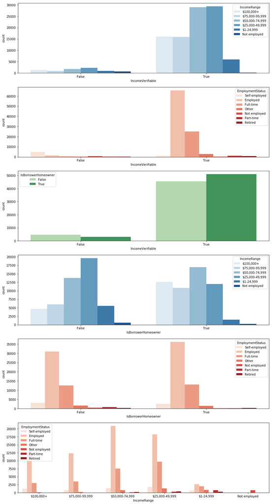

```python
# Plot a faceted clustered bar chart for the relationships between categorical variables

plt.figure(figsize = [15, 30])

plt.subplot(6, 1, 1)
sb.countplot(data = loans, x = 'IncomeVerifiable', hue = 'IncomeRange', palette = 'Blues')

ax = plt.subplot(6, 1, 2)
sb.countplot(data = loans, x = 'IncomeVerifiable', hue = 'EmploymentStatus', palette = 'Reds')

ax = plt.subplot(6, 1, 3)
sb.countplot(data = loans, x = 'IncomeVerifiable', hue = 'IsBorrowerHomeowner', palette = 'Greens')

ax = plt.subplot(6, 1, 4)
sb.countplot(data = loans, x = 'IsBorrowerHomeowner', hue = 'IncomeRange', palette = 'Blues')

ax = plt.subplot(6, 1, 5)
sb.countplot(data = loans, x = 'IsBorrowerHomeowner', hue = 'EmploymentStatus', palette = 'Reds')

ax = plt.subplot(6, 1, 6)
sb.countplot(data = loans, x = 'IncomeRange', hue = 'EmploymentStatus', palette = 'Reds')

plt.show()
```

Outside of this, there's not much I gathered from the plots above.

### Bivariate Exploration Summary

Many interesting relationships were uncovered in this section. Some of the ones with the main feature of interest, the `BorrowerAPR` are as per below:

- `BorrowerAPR` is negatively correlated with credit score.
- `BorrowerAPR` is negatively correlated with loan amount.
- The income range has a clear effect on `BorrowerAPR` with higher income ranges having lower `BorrowerAPR`.
- Whether or not the income could be verified has a clear effect on `BorrowerAPR` with verified incomes having much lower `BorrowerAPR`.
- Employment status influences `BorrowerAPR` with more stable employment having lower overall `BorrowerAPR`.
- It was interesting that the open credit lines, employment duration and home loan status didn't effect `BorrowerAPR` much.

## Multivariate Exploration

For this section, I'm most interested in looking multivariate relationships between variables we know has an effect on borrower APR from the last section. These variables are: Credit Score, Loan Amount, Income Range, Income Verifiability and Employment Status. Now, because the Employment Status data we have is not very clear, we will ignore that one.

I'm most interested in the following relationships:

- Relationship between borrower APR, credit score and income verifiability. E.g. If someone with an unverifiable income has a high credit rating, does it effect their borrower APR?
- Relationship between borrower APR, income range and loan amount. E.g. If someone within a lower income range asks for a bigger loan, does that reduce their borrower APR?
- Relationship between borrower APR, credit score and loan amount. E.g. Does the loan amount effects someone's borrower APR if their credit score is low/high?

First, let's look at the relationship between borrower APR, credit score and income verifiability.

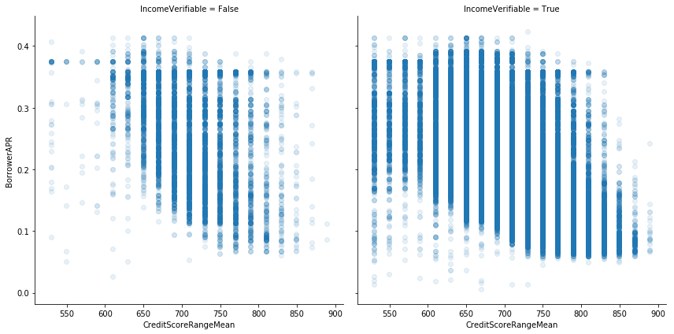

```python
# Plot the relationship between borrower APR, credit score and income verifiability.

import warnings
warnings.filterwarnings("ignore")

g = sb.FacetGrid(data = loans, col = 'IncomeVerifiable', size = 6);
g.map(plt.scatter, 'CreditScoreRangeMean', 'BorrowerAPR', alpha = 0.1);
```

Looking at the plot above, we can see that:

- Not many loans are given where the credit score is lower and income is not verifiable.
- Generally speaking, if the income is not verifiable, a higher credit score is required to get the same borrower APR compared to when the income is verified.

Now, let's look at the relationship between borrower APR, income range and loan amount.

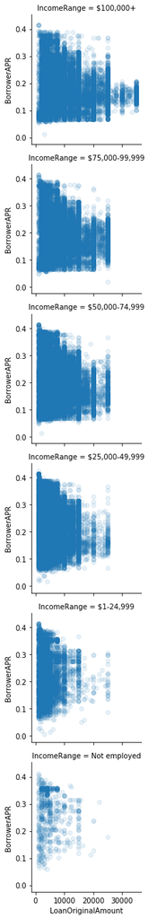

```python
# Plot the relationship between borrower APR, income range and loan amount.

g = sb.FacetGrid(data = loans, row = 'IncomeRange', size = 3);
g.map(plt.scatter, 'LoanOriginalAmount', 'BorrowerAPR', alpha = 0.1);
```

Looking at the plot above, we can see that generally larger loans are not given out to people with lower income. The relationship between borrower APR and loan amount doesn't seem to be impacted by income range.

Lastly, let's look at the relationship between borrower APR, credit score and loan amount.

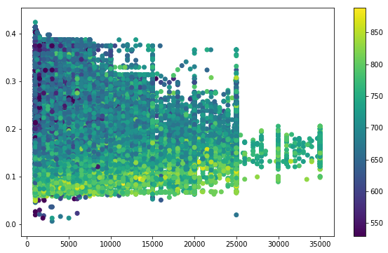

```python
# plot data between borrower APR, credit score and loan amount.

plt.figure(figsize = [10,6])
plt.scatter(data = loans, x = 'LoanOriginalAmount', y = 'BorrowerAPR', c = 'CreditScoreRangeMean')
plt.colorbar()
plt.show()
```

From the plot above, it's apparent that both higher loan amount and credit score contributes to a lower borrower APR.

### Multivariate Exploration Summary

From the exploration in this section, I found that:

- If the income is not verifiable, a higher credit score is required to get the same borrower APR compared to when the income is verified.
- The income range can effect the loan amount. Lower income ranges do not usually have larger loans.
- The loan amount and credit score variables strengthened each other. They are both negatively correlated with borrower APR.